# Lab 4 Assignment

Dylan Berneman

2023-04-27

### Part 1: Data Import

In this question we keep studying Task 1 in Lab 4 where we import monthly-australian-wine-sales-th.csv and use ts() command.

```r
wine.csv = read.table("monthly-australian-wine-sales-th.csv",
sep=",", header=FALSE, skip=1, nrows=187)
```

#### Question 1

Compare the plots of the series ‘wine1’ and ‘wine’ defined below, and state why we use ‘frequency=12’ in the lab material.

```
   wine1 = ts(wine.csv[,2], start = c(1980,1))
```

[figure not shown]

```
   wine = ts(wine.csv[,2], start = c(1980,1), frequency = 12)
```

```r
wine1 = ts(wine.csv[,2], start = c(1980,1), frequency = 12)
plot.ts(wine1)
```

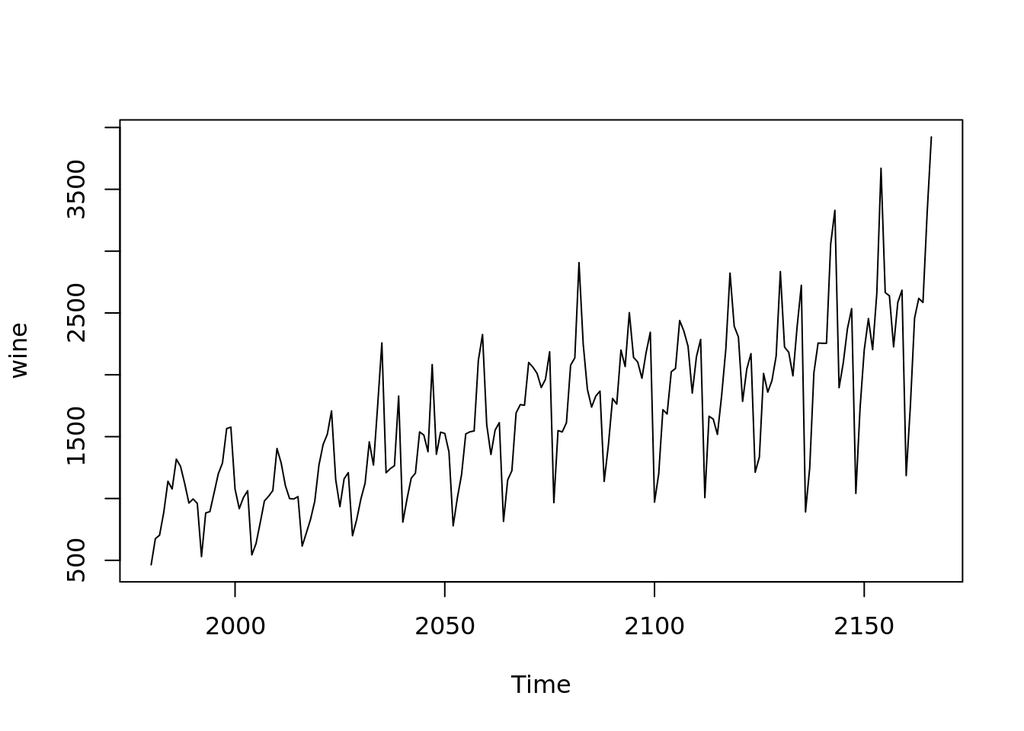

```r
wine = ts(wine.csv[,2], start = c(1980,1))
plot.ts(wine)
```

Both plots are visually identical. The only difference is the x-axis. The time for `wine1` ranges from the years 1980 through the middle of 1995. Meanwhile, the time for `wine` ranges from the years 1980 through 2167. In the data set, `wine.csv`, the time variable is in a date format “YYYY/MM”. When creating the time series, the start time is 1980/01. If we use the default of `Frequency`, 1, then that tells the code that each successive observation occurs 1 year later. By changing `Frequency` to 12, the code is told that the each successive observation occurs 1/12 of a year later, which is what we want.

#### Question 2

If you have a daily data of wine sales, for example from Jan 1, 1981 to Dec 31,1983. What value would you put in ‘frequency=’ so that the plot shows the correct year index on x-axis?

If we had daily data, we would have to set the frequency to 365, which is the amount of days in a year.

### Part 2: Data Tranformation

We introduce the Time Series Data Library (TSDL) created by Professor Rob Hyndman.(https://rdrr.io/ github/FinYang/tsdl/f/vignettes/tsdl.Rmd) Run the following code to import quarterly Iowa nonfarm income in R:

```r
#install.packages("devtools")
install.packages("forecast")
devtools::install_github("FinYang/tsdl")
library(tsdl)
library(forecast)
meta_tsdl$description[[1]]
```

```
## [1] "Quarterly Iowa nonfarm income (1948 – 1979)"
```

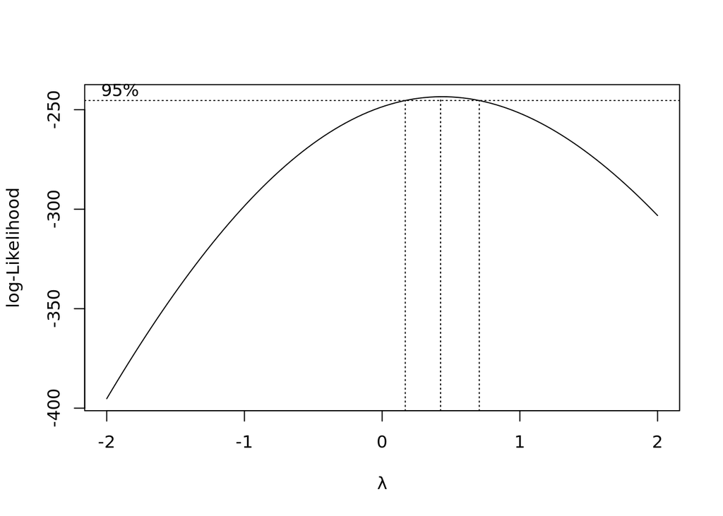

```r
iowa.ts <- tsdl[[1]]

library(MASS)
t = 1:length(wine1)
fit = lm(wine1 ~ t)
bcTransform = boxcox(wine1 ~ t,plotit = TRUE)
```

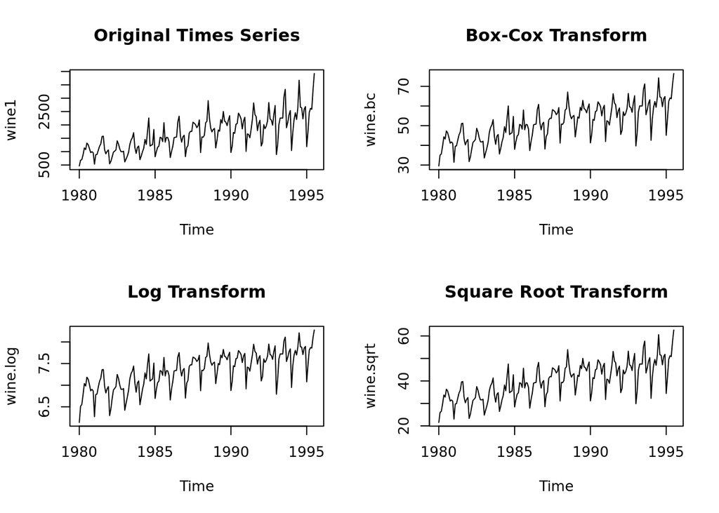

```r
lambda = bcTransform$x[which(bcTransform$y == max(bcTransform$y))]
wine.bc = (1/lambda)*(wine1^lambda-1)

#log transform
wine.log = log(wine1)
# square root transform
wine.sqrt = sqrt(wine1)
#Compare transforms
op= par(mfrow=c(2,2))
ts.plot(wine1, main = "Original Times Series")
ts.plot(wine.bc, main = "Box-Cox Transform")
ts.plot(wine.log, main = "Log Transform")
ts.plot(wine.sqrt, main = "Square Root Transform")
```